# **STEP 1: PROBLEM STATEMENT**

Loan approval is vital in the financial sector, determining applicants' eligibility for credit based on financial profiles. This process impacts individuals’ access to funds for essential needs and affects lenders’ profitability and risk. It involves assessing factors like credit scores, income, and employment to grant loans responsibly, minimizing default risk. However, the process can be time-consuming and inconsistent, impacting efficiency and fairness in lending.A comprehensive evaluation process ensures that loans are granted responsibly to applicants who are most likely to repay, reducing the risk of default.

This is a classification problem where we have to predict whether a loan will be approved or not. Specifically, it is a binary classification problem where we have to predict either one of the two classes given i.e. approved or not approved

# **STEP 1.1: EXPECTED OUTCOME**

The expected outcome of this loan approval prediction project is a robust, data-driven model capable of accurately predicting loan approval status based on applicants' financial and personal information, such as credit scores, income levels, employment status, and asset values. This model will help streamline the approval process, improve consistency in decision-making, and enhance fairness by reducing potential biases. Additionally, the analysis will offer insights into key factors influencing loan approval, enabling lending institutions to make informed, risk-aware decisions that support both applicant needs and organizational goals.

# **STEP 1.2: OBJECTIVE**

The objective of this loan approval prediction project is to develop a reliable predictive model that identifies the likelihood of loan approval based on applicants' financial and demographic characteristics.

1. Improve Decision-Making Efficiency: Reduce the time and resources required for manual loan assessment.
2. Enhance Consistency and Fairness: Provide a standardized approach to loan approval, minimizing human bias.
3. Identify Key Predictive Factors: Offer insights into the most influential attributes in loan approval, helping to guide lending policies and strategies.
4. Mitigate Default Risk: Enable responsible lending by approving loans for applicants with a high probability of repayment, reducing the institution's risk exposure.

# **1.3: LOADING NECESSARY LIBRARIES**

```python
import pandas as pd
import numpy as np
import matplotlib.pyplot as plt
import seaborn as sns
import warnings
warnings.filterwarnings('ignore')
```

# **1.4: LOADING THE DATA**

The [loan approval dataset](https://www.kaggle.com/datasets/architsharma01/loan-approval-prediction-dataset) is a collection of financial records and associated information used to determine the eligibility of individuals or organizations for obtaining loans from a lending institution. It includes various factors such as cibil score, income, employment status, loan term, loan amount, assets value, and loan status.

The dependent variable or target variable is the Loan_Status, while the rest are independent variable or features.

```python
loan_df = pd.read_csv('loan_approval_dataset.csv')
```

```python
loan_df.head()
```

|  | loan_id | no_of_dependents | education | self_employed | income_annum | loan_amount | loan_term | cibil_score | residential_assets_value | commercial_assets_value | luxury_assets_value | bank_asset_value | loan_status |
| --- | --- | --- | --- | --- | --- | --- | --- | --- | --- | --- | --- | --- | --- |
| 0 | 1 | 2 | Graduate | No | 9600000 | 29900000 | 12 | 778 | 2400000 | 17600000 | 22700000 | 8000000 | Approved |
| 1 | 2 | 0 | Not Graduate | Yes | 4100000 | 12200000 | 8 | 417 | 2700000 | 2200000 | 8800000 | 3300000 | Rejected |
| 2 | 3 | 3 | Graduate | No | 9100000 | 29700000 | 20 | 506 | 7100000 | 4500000 | 33300000 | 12800000 | Rejected |
| 3 | 4 | 3 | Graduate | No | 8200000 | 30700000 | 8 | 467 | 18200000 | 3300000 | 23300000 | 7900000 | Rejected |
| 4 | 5 | 5 | Not Graduate | Yes | 9800000 | 24200000 | 20 | 382 | 12400000 | 8200000 | 29400000 | 5000000 | Rejected |

# **2. DESCRIPTIVE STATISTICS**

To understand its structure, including the number of records, columns, and data types.

```python
loan_df.shape
#(rows, columns)
```

```
(4269, 13)
```

```python
loan_df.info()
```

```
<class 'pandas.core.frame.DataFrame'>
RangeIndex: 4269 entries, 0 to 4268
Data columns (total 13 columns):
 #   Column                     Non-Null Count  Dtype
---  ------                     --------------  -----
 0   loan_id                    4269 non-null   int64
 1    no_of_dependents          4269 non-null   int64
 2    education                 4269 non-null   object
 3    self_employed             4269 non-null   object
 4    income_annum              4269 non-null   int64
 5    loan_amount               4269 non-null   int64
 6    loan_term                 4269 non-null   int64
 7    cibil_score               4269 non-null   int64
 8    residential_assets_value  4269 non-null   int64
 9    commercial_assets_value   4269 non-null   int64
 10   luxury_assets_value       4269 non-null   int64
 11   bank_asset_value          4269 non-null   int64
 12   loan_status               4269 non-null   object
dtypes: int64(10), object(3)
memory usage: 433.7+ KB
```

There are 2 data types in the data

1. object: Object format means variables are categorical. Categorical variables in our dataset are:Education, Self_Employed,Loan_Status
2. nt64: It represents the integer variables.The rest of the columns are in this format.

Datatypes are an important concept because statistical methods can only be used with certain data types.

We will have to convert the catergorical variables into numerical format for statistiscal analysis.

```python
loan_df.describe()
```

|  | loan_id | no_of_dependents | income_annum | loan_amount | loan_term | cibil_score | residential_assets_value | commercial_assets_value | luxury_assets_value | bank_asset_value |
| --- | --- | --- | --- | --- | --- | --- | --- | --- | --- | --- |
| count | 4269.000000 | 4269.000000 | 4.269000e+03 | 4.269000e+03 | 4269.000000 | 4269.000000 | 4.269000e+03 | 4.269000e+03 | 4.269000e+03 | 4.269000e+03 |
| mean | 2135.000000 | 2.498712 | 5.059124e+06 | 1.513345e+07 | 10.900445 | 599.936051 | 7.472617e+06 | 4.973155e+06 | 1.512631e+07 | 4.976692e+06 |
| std | 1232.498479 | 1.695910 | 2.806840e+06 | 9.043363e+06 | 5.709187 | 172.430401 | 6.503637e+06 | 4.388966e+06 | 9.103754e+06 | 3.250185e+06 |
| min | 1.000000 | 0.000000 | 2.000000e+05 | 3.000000e+05 | 2.000000 | 300.000000 | -1.000000e+05 | 0.000000e+00 | 3.000000e+05 | 0.000000e+00 |
| 25% | 1068.000000 | 1.000000 | 2.700000e+06 | 7.700000e+06 | 6.000000 | 453.000000 | 2.200000e+06 | 1.300000e+06 | 7.500000e+06 | 2.300000e+06 |
| 50% | 2135.000000 | 3.000000 | 5.100000e+06 | 1.450000e+07 | 10.000000 | 600.000000 | 5.600000e+06 | 3.700000e+06 | 1.460000e+07 | 4.600000e+06 |
| 75% | 3202.000000 | 4.000000 | 7.500000e+06 | 2.150000e+07 | 16.000000 | 748.000000 | 1.130000e+07 | 7.600000e+06 | 2.170000e+07 | 7.100000e+06 |
| max | 4269.000000 | 5.000000 | 9.900000e+06 | 3.950000e+07 | 20.000000 | 900.000000 | 2.910000e+07 | 1.940000e+07 | 3.920000e+07 | 1.470000e+07 |

# **2.1: EXPLORATORY DATA ANALYSIS(EDA)**

understanding the dataset's underlying patterns, relationships, and potential anomalies before diving into modeling or making predictions. EDA typically involves visualizing data, identifying patterns, and uncovering important insights.

```python
loan_df.isnull().any()
#checking for null or missing values
```

|  | 0 |
| --- | --- |
| loan_id | False |
| no_of_dependents | False |
| education | False |
| self_employed | False |
| income_annum | False |
| loan_amount | False |
| loan_term | False |
| cibil_score | False |
| residential_assets_value | False |
| commercial_assets_value | False |
| luxury_assets_value | False |
| bank_asset_value | False |
| loan_status | False |

**dtype:** bool

```python
loan_df.isnull().sum()
```

|  | 0 |
| --- | --- |
| loan_id | 0 |
| no_of_dependents | 0 |
| education | 0 |
| self_employed | 0 |
| income_annum | 0 |
| loan_amount | 0 |
| loan_term | 0 |
| cibil_score | 0 |
| residential_assets_value | 0 |
| commercial_assets_value | 0 |
| luxury_assets_value | 0 |
| bank_asset_value | 0 |
| loan_status | 0 |

**dtype:** int64

```python
loan_df.duplicated().sum()
#checks for duplicate rows in the DataFrame loan_df
```

```
0
```

```python
print(loan_df.columns)
```

```
Index(['loan_id', ' no_of_dependents', ' education', ' self_employed',
       ' income_annum', ' loan_amount', ' loan_term', ' cibil_score',
       ' residential_assets_value', ' commercial_assets_value',
       ' luxury_assets_value', ' bank_asset_value', ' loan_status'],
      dtype='object')
```

```python
loan_df[' loan_status'].unique()
# checking for unique values in the loan_status column
```

```
array([' Approved', ' Rejected'], dtype=object)
```

```python
## Group by loan_status and review the output.
loan_gr = loan_df.groupby(' loan_status' , axis = 0)
pd.DataFrame(loan_gr.size(), columns=['# of observations'])
```

| loan_status | # of observations |
| --- | --- |
| Approved | 2656 |
| Rejected | 1613 |

Those approved are 2656 and those rejected are 1613. Lets visualize this to confirm.

# **2.2: VISUALIZATION**

# ** Univariate analysis**

Univariate analysis is when we analyze each variable individually. For categorical features we can use frequency table which will calculate the number of each category in a particular variable. For numerical features, a histogram is used.

## 1. VISUALIZING CATEGORICAL FEATURES

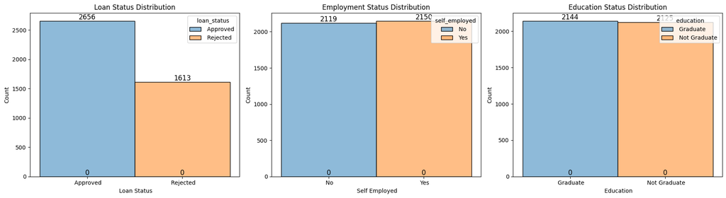

```python
fig, axs = plt.subplots(1, 3, figsize=(18, 5))  # Create 1 row and 3 columns of subplots

# List of features to plot
features = [' loan_status', ' self_employed' , ' education' ]
titles = ['Loan Status Distribution', 'Employment Status Distribution', 'Education Status Distribution']

# Loop through the features to create plots and add data labels
for ax, feature, title in zip(axs, features, titles):
    sns.histplot(data=loan_df, x=feature, hue=feature, ax=ax, kde=False)
    ax.set_title(title)
    ax.set_xlabel(feature.replace('_', ' ').title())
    ax.set_ylabel('Count')

    # Add data labels
    for container in ax.containers:
        ax.bar_label(container, fontsize=12)

# Adjust layout for better spacing
plt.tight_layout()
plt.show()

## hue: This will color the bars in the histogram based on different categories
#kde=False: No density curve will be plotted alongside the histogram bars
```

# INTERPRETATION:

2150 people are selfemployed while 2119 are not self_employed. There’s a roughly equal distribution between self-employed and non-self-employed applicants, meaning employment type is fairly balanced in the dataset.

2144 people are graduates and 2125 people are not graduates. the education status is also nearly equally distributed, with a slight majority of applicants having graduated.

Those approved are 2656 and those rejected are 1613. There are significantly more loans approved than rejected in this dataset.

# 2. VISUALIZING NUMERICAL FEATURES

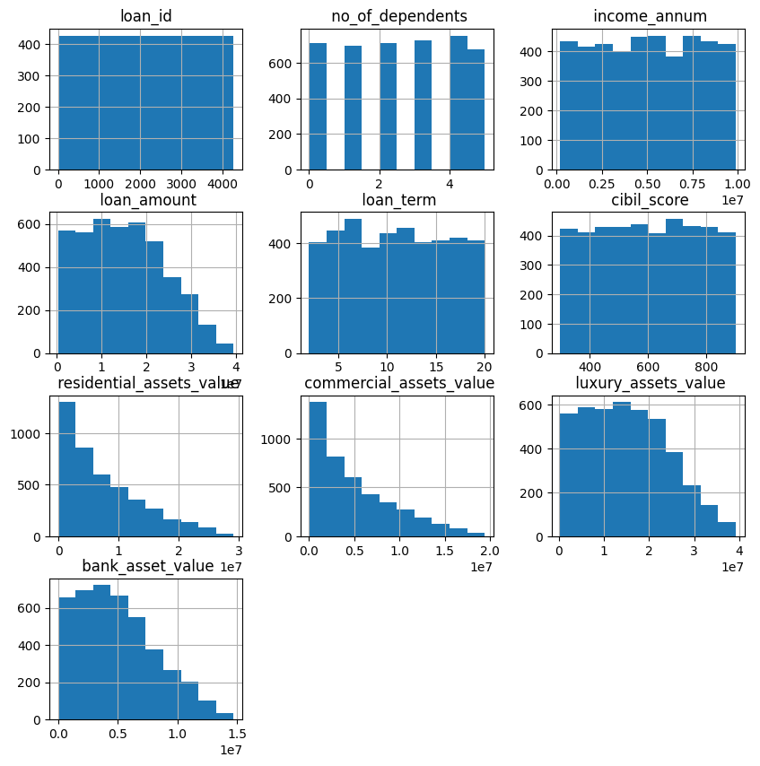

```python
#Histogram to visualize the numerical features- to show the distribution of the data
loan_df.hist(figsize=(10,10))
plt.show()
```

## BIVARIATE ANALYSIS-

Refers to analysis of two variables to understand the relationship or association between them

**1. Categorical Independent Variable vs Target Variable**

BAR PLOTS TO VISUALIZE LOAN STATUS BY EMPLOYMENT AND EDUCATION STATUS

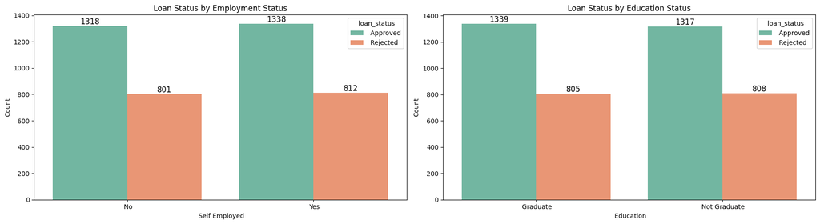

```python
fig, axs = plt.subplots(1, 2, figsize=(18, 5))  # Create 1 row and 3 columns of subplots

# List of features to plot
features = [' self_employed', ' education']
titles = ['Loan Status by Employment Status', 'Loan Status by Education Status' ]

# Loop through the features to create plots and add data labels
for ax, feature, title in zip(axs, features, titles):
    sns.countplot(data=loan_df, x=feature, hue=' loan_status', ax=ax,  palette='Set2' )
    ax.set_title(title)
    ax.set_xlabel(feature.replace('_', ' ').title())
    ax.set_ylabel('Count')
#The palette parameter in seaborn controls the colors used for the different elements (bars,

    # Add data labels
    for container in ax.containers:
        ax.bar_label(container, fontsize=12)

# Adjust layout for better spacing
plt.tight_layout()
plt.show()
```

# INTERPRETATION:

1338 self_employed people were approved for a loan.  
812 self_employed people were rejected for a loan.

1318 non self_employed people were approved for a loan.

801 non self_employed people were rejected for a loan

The number of loan approvals is consistently higher than the rejections for both self-employed and non-self-employed individuals. Being self-employed does not appear to significantly impact the likelihood of loan approval compared to not being self-employed.

==========================================================

1339 Graduates were approved for a loan. 805 Graduates were rejected for a loan.

1317 Non-Graduates were approved for a loan.

808 Non_Graduates were rejected for a loan

The pattern of loan approval is similar for both graduates and non-graduates, with more approvals than rejections in both categories. Education status (being a graduate or not) seems to have a minimal impact on the loan approval rate.

In both charts, the counts of loan approvals are consistently higher than rejections across all categories (employment and education status), suggesting that these factors may not be the primary determinants of loan approval decisions in this dataset.

2**. Numerical Independent Variable VS target variable**

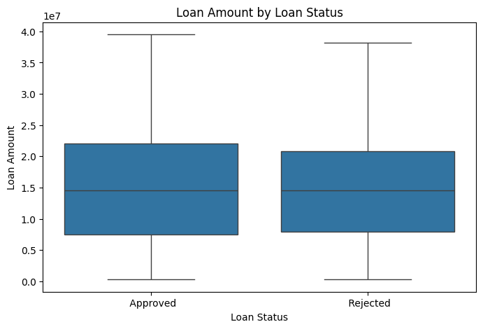

```python
# Box plot to analyze the relationship between loan_status and loan_amount
plt.figure(figsize=(8, 5))
sns.boxplot(x=' loan_status', y= ' loan_amount', data=loan_df)

# Add title and labels
plt.title('Loan Amount by Loan Status')
plt.xlabel('Loan Status')
plt.ylabel('Loan Amount')

plt.show()
```

INTERPRETATION

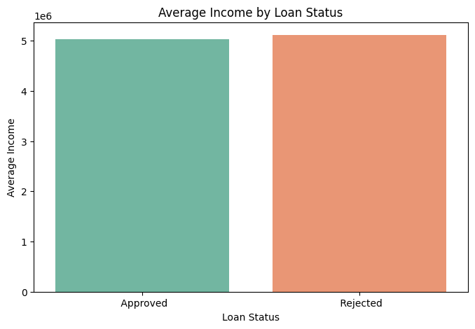

```python
#bar chart to analyze the relationship between loan_status and average income
# Group by loan_status and calculate the mean of income
avg_income_by_status = loan_df.groupby(' loan_status')[' income_annum'].mean().reset_index()

# Plot a bar chart
plt.figure(figsize=(8, 5))
sns.barplot(x=' loan_status', y= ' income_annum', hue=' loan_status', data=avg_income_by_status, palette='Set2')

# Add title and labels
plt.title('Average Income by Loan Status')
plt.xlabel('Loan Status')
plt.ylabel('Average Income')

# Show the plot
plt.show()
```

INTERPRETATION

1. Both bars are of nearly the same height, suggesting that there is little to no significant difference in the average income between those who had their loans approved and those who had them rejected. The average income is around 5 million units for both groups.
2. This implies that income may not be the primary factor influencing the approval or rejection of loans in this dataset.

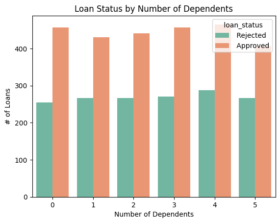

```python
#bar chart to analyze the relationshhip between no of dependents and loan_status
# Create a count plot with 'dependents' on the x-axis and 'loan_status' as hue
sns.countplot(x=' no_of_dependents', hue=' loan_status', data=loan_df, palette='Set2')

# Add title and labels
plt.title('Loan Status by Number of Dependents')
plt.xlabel('Number of Dependents')
plt.ylabel('# of Loans')

# Show the plot
plt.show()
```

INTERPRETATION

1. For every category of dependents (0 to 5), the number of approved loans (in orange) is consistently higher than the number of rejected loans (in green). This suggests that, regardless of the number of dependents, the likelihood of loan approval is generally higher than rejection.
2. No Dependents (0): The number of approved loans is much higher compared to rejected loans, indicating a higher approval rate for individuals with no dependents.
3. 1, 2, 3, 4, and 5 Dependents: A similar pattern can be observed, where approved loans outnumber rejected loans, though the gap between approved and rejected loans narrows slightly as the number of dependents increases.
4. The number of loans in each category (whether approved or rejected) appears to be fairly consistent across different dependent categories, suggesting that the number of dependents may not be a very strong factor influencing loan approval in this dataset.
5. From this chart, it can be inferred that the number of dependents does not have a dramatic effect on loan approval, but there is a slight decrease in approval rates as the number of dependents increases.

3**. correlation between all the numerical variables** -

The variables with darker color means their correlation is more.

|  | loan_id | no_of_dependents | income_annum | loan_amount | loan_term | cibil_score | residential_assets_value | commercial_assets_value | luxury_assets_value | bank_asset_value |
| --- | --- | --- | --- | --- | --- | --- | --- | --- | --- | --- |
| loan_id | 1.000000 | 0.005326 | 0.012592 | 0.008170 | 0.009809 | 0.016323 | 0.020936 | 0.018595 | -0.000862 | 0.010765 |
| no_of_dependents | 0.005326 | 1.000000 | 0.007266 | -0.003366 | -0.020111 | -0.009998 | 0.007376 | -0.001531 | 0.002817 | 0.011163 |
| income_annum | 0.012592 | 0.007266 | 1.000000 | 0.927470 | 0.011488 | -0.023034 | 0.636841 | 0.640328 | 0.929145 | 0.851093 |
| loan_amount | 0.008170 | -0.003366 | 0.927470 | 1.000000 | 0.008437 | -0.017035 | 0.594596 | 0.603188 | 0.860914 | 0.788122 |
| loan_term | 0.009809 | -0.020111 | 0.011488 | 0.008437 | 1.000000 | 0.007810 | 0.008016 | -0.005478 | 0.012490 | 0.017177 |
| cibil_score | 0.016323 | -0.009998 | -0.023034 | -0.017035 | 0.007810 | 1.000000 | -0.019947 | -0.003769 | -0.028618 | -0.015478 |
| residential_assets_value | 0.020936 | 0.007376 | 0.636841 | 0.594596 | 0.008016 | -0.019947 | 1.000000 | 0.414786 | 0.590932 | 0.527418 |
| commercial_assets_value | 0.018595 | -0.001531 | 0.640328 | 0.603188 | -0.005478 | -0.003769 | 0.414786 | 1.000000 | 0.591128 | 0.548576 |
| luxury_assets_value | -0.000862 | 0.002817 | 0.929145 | 0.860914 | 0.012490 | -0.028618 | 0.590932 | 0.591128 | 1.000000 | 0.788517 |
| bank_asset_value | 0.010765 | 0.011163 | 0.851093 | 0.788122 | 0.017177 | -0.015478 | 0.527418 | 0.548576 | 0.788517 | 1.000000 |

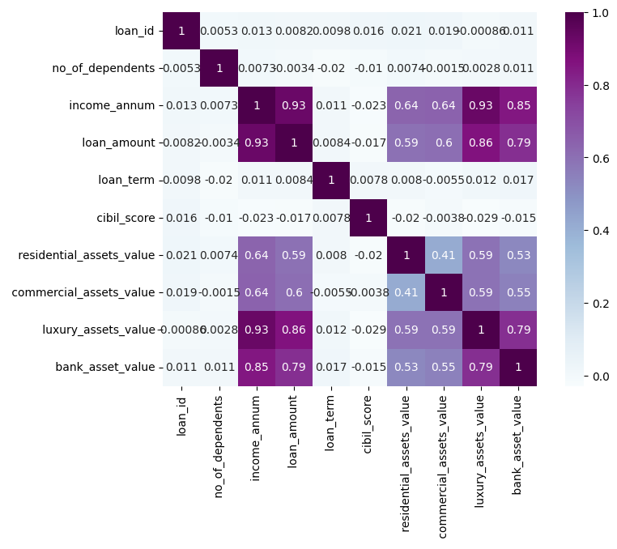

```python
#correlation between all the numerical variables
# calculate and visualize correlation matrix
correlation_matrix = loan_df.drop(columns=[' education', ' self_employed',' loan_status']).corr()
f, ax = plt.subplots(figsize=(9, 6))
sns.heatmap(correlation_matrix, vmax=1, square=True, cmap="BuPu", annot=True)

correlation_matrix
```

# INTERPRETATION:

**Strong Positive Correlations:**

1. income_annum and loan_amount: The correlation is 0.93, indicating a strong positive relationship. This suggests that as the annual income increases, the loan amount tends to increase as well.
2. income_annum and luxury_assets_value: A high correlation of 0.93 indicates that individuals with higher income are more likely to have higher values of luxury assets.
3. luxury_assets_value and loan_amount: The correlation is 0.86, showing a strong relationship between the value of luxury assets and the loan amount.
4. income_annum and bank_asset_value: With a correlation of 0.85, this suggests that higher income is associated with higher bank asset values.

**Weak Correlations:**

1. Most variables like no_of_dependents, loan_term, and cibil_score have very low correlations (close to zero) with other variables, suggesting that they do not have a strong direct relationship with the other factors in this dataset.

The matrix shows that financial factors (income, asset values, and loan amount) have relatively strong interconnections, suggesting that individuals with higher incomes are more likely to have higher asset values and take larger loan amounts.

# **3. DATA PREPROCESSING**

```python
print(loan_df.columns)
```

```
Index(['loan_id', ' no_of_dependents', ' education', ' self_employed',
       ' income_annum', ' loan_amount', ' loan_term', ' cibil_score',
       ' residential_assets_value', ' commercial_assets_value',
       ' luxury_assets_value', ' bank_asset_value', ' loan_status'],
      dtype='object')
```

```python
#Droping the loan_id since its redundant and not useful
loan_df.drop('loan_id', axis=1, inplace=True)
#inplace=True: Directly applies the change to the DataFrame without needing to reassign it.
```

```python
loan_df.head()
```

|  | no_of_dependents | education | self_employed | income_annum | loan_amount | loan_term | cibil_score | residential_assets_value | commercial_assets_value | luxury_assets_value | bank_asset_value | loan_status |
| --- | --- | --- | --- | --- | --- | --- | --- | --- | --- | --- | --- | --- |
| 0 | 2 | Graduate | No | 9600000 | 29900000 | 12 | 778 | 2400000 | 17600000 | 22700000 | 8000000 | Approved |
| 1 | 0 | Not Graduate | Yes | 4100000 | 12200000 | 8 | 417 | 2700000 | 2200000 | 8800000 | 3300000 | Rejected |
| 2 | 3 | Graduate | No | 9100000 | 29700000 | 20 | 506 | 7100000 | 4500000 | 33300000 | 12800000 | Rejected |
| 3 | 3 | Graduate | No | 8200000 | 30700000 | 8 | 467 | 18200000 | 3300000 | 23300000 | 7900000 | Rejected |
| 4 | 5 | Not Graduate | Yes | 9800000 | 24200000 | 20 | 382 | 12400000 | 8200000 | 29400000 | 5000000 | Rejected |

```python
loan_df.shape
```

```
(4269, 12)
```

```python
print(loan_df.columns)
```

```
Index([' no_of_dependents', ' education', ' self_employed', ' income_annum',
       ' loan_amount', ' loan_term', ' cibil_score',
       ' residential_assets_value', ' commercial_assets_value',
       ' luxury_assets_value', ' bank_asset_value', ' loan_status'],
      dtype='object')
```

```python
X = loan_df.drop(' loan_status', axis=1) #feature variables
y = loan_df[' loan_status'] #target variables
```

```python
#converting categorical variables to numerical format
from sklearn.preprocessing import LabelEncoder
le = LabelEncoder()

categorical_columns = [' education', ' self_employed' ]

for column in categorical_columns:
    X[column] = le.fit_transform(X[column])

y = le.fit_transform(y)
```

```python
y
```

```
array([0, 1, 1, ..., 1, 0, 0])
```

```python
X[' education' ]
```

|  | education |
| --- | --- |
| 0 | 0 |
| 1 | 1 |
| 2 | 0 |
| 3 | 0 |
| 4 | 1 |
| ... | ... |
| 4264 | 0 |
| 4265 | 1 |
| 4266 | 1 |
| 4267 | 1 |
| 4268 | 0 |

4269 rows × 1 columns

**dtype:** int64

FEATURE STANDADIZATION

```python
from sklearn.preprocessing import StandardScaler

scaler =StandardScaler()
X = scaler.fit_transform(X)
```

SPLITTING THE DATA INTO TRAINING AND TESTING DATASETS

```python
from sklearn.model_selection import train_test_split

##Split data set in train 80% and test 20%
X_train, X_test, y_train, y_test = train_test_split( X, y, test_size=0.2, random_state=7)
#Using the same random_state value will produce the same split each time you run the code.
```

```python
X_train.shape, y_train.shape, X_test.shape, y_test.shape
#The shapes are represented as tuples (number of samples, number ofn features) for X and (number of samples,) for y.
```

```
((3415, 11), (3415,), (854, 11), (854,))
```

# **4. MODEL TRAINING**

```python
from sklearn.linear_model import LogisticRegression
model = LogisticRegression()
model.fit(X_train, y_train)
```

```
LogisticRegression()
```

# 5. MODEL EVALUATION

```python
# Predict on the test data
y_pred = model.predict(X_test)

# Evaluate the model
from sklearn.metrics import accuracy_score, precision_score, recall_score, f1_score, confusion_matrix

accuracy = accuracy_score(y_test, y_pred)
precision = precision_score(y_test, y_pred)
recall = recall_score(y_test, y_pred)
f1 = f1_score(y_test, y_pred)
conf_matrix = confusion_matrix(y_test, y_pred)

# Display the metrics
print(f'Accuracy: {accuracy:.2f}')
print(f'Precision: {precision:.2f}')
print(f'Recall: {recall:.2f}')
print(f'F1-Score: {f1:.2f}')
print(f'Confusion Matrix:\n{conf_matrix}')
```

```
Accuracy: 0.92
Precision: 0.91
Recall: 0.88
F1-Score: 0.89
Confusion Matrix:
[[491  30]
 [ 39 294]]
```

So our predictions are over 92% accurate, i.e. we have identified 92% of the loan status correctly.

The performance of our model seems encouraging, with accuracy of 92%, precision of 91% and recall of 88%.

```python
from sklearn.metrics import classification_report
print(classification_report(y_test, y_pred))
```

```
              precision    recall  f1-score   support

           0       0.93      0.94      0.93       521
           1       0.91      0.88      0.89       333

    accuracy                           0.92       854
   macro avg       0.92      0.91      0.91       854
weighted avg       0.92      0.92      0.92       854
```

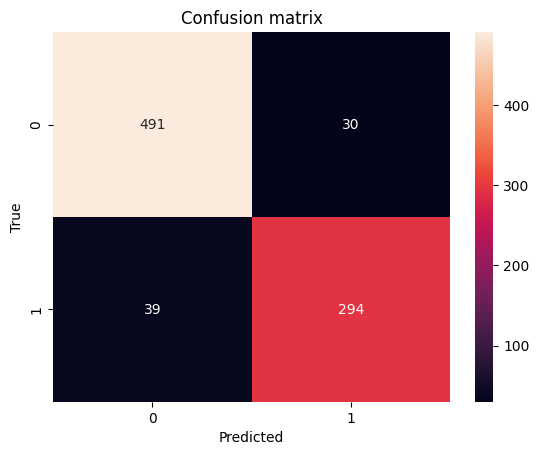

```python
#heatmap to visualize the confusion matrix
import seaborn as sns
sns.heatmap(confusion_matrix(y_test, y_pred), annot=True, fmt='g')
plt.title('Confusion matrix')
plt.xlabel('Predicted')
plt.ylabel('True') #actual
```

# Interpretation:

1. Rows represent the true values (actual labels).
2. Columns represent the predicted values from the model.
3. True Positives (TP): The model correctly predicted 294 instances of the positive class (1).
4. True Negatives (TN): The model correctly predicted 491 instances of the negative class (0).
5. False Positives (FP): The model incorrectly predicted 30 instances as positive when they were actually negative.
6. False Negatives (FN): The model incorrectly predicted 39 instances as negative when they were actually positive.

# 6. Grid search

We will try to improve the accuracy by tuning the hyperparameters for this model. We will use grid search to get the optimized values of hyper parameters. GridSearch is a way to select the best of a family of hyper parameters, parametrized by a grid of parameters.

**Grid Search** - This is an exhaustive search method that helps you automatically find the best combination of hyperparameters for your machine learning model. Instead of manually trying out different values for hyperparameters, GridSearchCV does it for you by testing all possible combinations of the specified hyperparameter values and selecting the best one based on the scoring metric.

```python
from sklearn.model_selection import GridSearchCV
```

```python
model = LogisticRegression(max_iter=1000)

# Define the hyperparameters and their values to search
param_grid = {
    'C': [0.01, 0.1, 1, 10, 100],      # Inverse of regularization strength
    'solver': ['liblinear', 'saga'],  # Optimization algorithm
    'penalty': ['l1', 'l2'],           # Regularization type
}

#l1 and l2 correspond to Lasso and Ridge regularization, respectively.
#The grid search will try all possible combinations of these hyperparameters (5 values of C, 2 solvers, and 2 penalties), meaning a total of 20 combinations will be tested.
```

```python
grid_search = GridSearchCV(estimator=model, param_grid=param_grid,
                           scoring='accuracy', cv=5, n_jobs=-1)

#cv=5: This specifies 5-fold cross-validation, meaning the data will be split into 5 subsets.
#The model will be trained on 4 of the subsets and tested on the remaining one.
#This will repeat 5 times, rotating the test set each time, and the results will be averaged.
```

```python
grid_search.fit(X_train, y_train)
```

```
GridSearchCV(cv=5, estimator=LogisticRegression(max_iter=1000), n_jobs=-1,
             param_grid={'C': [0.01, 0.1, 1, 10, 100], 'penalty': ['l1', 'l2'],
                         'solver': ['liblinear', 'saga']},
             scoring='accuracy')
```

```python
print(f'Best Parameters: {grid_search.best_params_}') #This returns the best hyperparameter combination found during the grid search
print(f'Best Cross-Validation Score: {grid_search.best_score_:.2f}')  #This gives the highest accuracy score obtained during cross-validation with the best combination of hyperparameters.
```

```
Best Parameters: {'C': 0.01, 'penalty': 'l1', 'solver': 'liblinear'}
Best Cross-Validation Score: 0.94
```

The initial accuracy of 92% and the current best cross-validation score of 94% indicate that the hyperparameter tuning has improved the model's performance.